# 01_221805084

### 1. Project Setup: Importing Libraries and Defining Core Parameters

This initial code cell sets up the foundation for our project. We import the necessary libraries for data manipulation and signal processing, and define the core constants and parameters related to our dataset and analysis.

```python
import os
import pandas as pd
import numpy as np
import glob
from scipy.stats import skew, kurtosis
from scipy.fft import rfft, rfftfreq

DATASET_DIR = 'PM980'
csv_files = [file for file in os.listdir(DATASET_DIR) if file.endswith('.csv')]
RANDOM_SEED = 13

# Sensor columns to extract time/frequency features from
SENSOR_COLUMNS = [
    'Voice', 'Acceleration X', 'Acceleration Y', 'Acceleration Z',
    'Gyro X', 'Gyro Y', 'Gyro Z', 'Temperature'
]
SAMPLING_RATE = 90  # Hz

def get_label(filename):
    # Handle typo
    if "scracth" in filename:
        filename.replace("scracth", "scratch")

    if 'healthy' in filename.lower():
        return 'healthy'

    damage_types = ['notchlong', 'notchshort', 'scracth', 'singlecutlong',
                    'singlecutshort', 'twocutlong', 'twocutshort', 'warped']

    for damage in damage_types:
        if damage in filename.lower():
            return damage

    return 'unknown'
```

### 2. Helper Function: Extracting Metadata from Filenames

The files in our dataset follow a specific naming convention (`speed-start_speed-end_...`) that encodes not only the signal's class but also valuable information about the measurement conditions. This helper function, `extract_info_from_filename`, is designed to programmatically parse this structured information.

**Function's Purpose:**

- The function takes a filename as input and splits it based on the underscore (`_`) delimiter.
- It then extracts the following metadata from the resulting parts:
  - **Speed Range (`speed_range_start`, `speed_range_end`):** It converts the speed range at which the signal was recorded into a numerical (float) value. This is a critical step to fulfill the project's **"Speed interval"** input requirement.
  - **Condition:** The environment where the measurement was taken (e.g., 'indoor' or 'outdoor').
  - **Noise Level:** Indicates whether the recording was noisy or clear.

**Error Handling:**

The code is made more robust using `try-except` blocks to handle cases where not all filenames might adhere to the same standard:

- `IndexError`: Prevents the program from crashing if a filename has fewer parts than expected, marking the missing information as `unknown` or `np.nan`.
- `ValueError`: If the speed range information cannot be converted to a number, it prints a warning and sets these values to `np.nan`.

Thanks to this function, we can augment our raw sensor data with this additional contextual information, which can be used as features or for better data understanding during the analysis phase.

```python
def extract_info_from_filename(filename):
    parts = filename.split('_')
    info = {}
    try:
        info['speed_range_start'] = float(parts[0])
        info['speed_range_end'] = float(parts[1])
        info['condition'] = parts[3]  # indoor/outdoor
        info['noise_level'] = parts[4] # clear/noisy
    except IndexError:
        print(f"Uyarı: '{filename}' dosya adından tüm bilgiler çıkarılamadı. Eksik parçalar olabilir.")
        info['speed_range_start'] = np.nan
        info['speed_range_end'] = np.nan
        info['condition'] = 'unknown'
        info['noise_level'] = 'unknown'
    except ValueError:
        print(f"Uyarı: '{filename}' dosya adındaki hız aralığı sayıya dönüştürülemedi.")
        info['speed_range_start'] = np.nan
        info['speed_range_end'] = np.nan

    return info
```

### 3. Feature Extraction Function: Deriving Meaningful Information from Signals

This code cell defines the `extract_signal_features` function, which is the core of our feature engineering process. Its primary purpose is to transform raw time-series sensor data (from a single signal) into a set of numerical features that machine learning models can understand and use for classification. In line with the project requirements, this function extracts **only time-domain and frequency-domain features**.

**How the Function Works:**

The function takes a single sensor signal (as a `pandas` Series) and the sampling rate as input. It then computes a variety of statistical features from this signal in both the time and frequency domains.

#### 3.1. Time-Domain Features

These features summarize the overall structure and distribution of the signal over time:

- **Basic Statistics:** `mean`, `std` (standard deviation), `var` (variance), `min`, `max`, and `range`.
- **Shape Descriptors:**
  - `skew`: Measures the asymmetry of the signal's distribution.
  - `kurtosis`: Measures the "tailedness" or "peakedness" of the distribution.
- **Energy and Power-Related Features:**
  - `rms` (Root Mean Square): Represents the effective power or magnitude of the signal.
  - `crest_factor`: The ratio of the peak value to the RMS value, which is useful for identifying sharp peaks in the signal.

#### 3.2. Frequency-Domain Features

These features provide information about the signal's frequency components and are calculated using the `scipy.fft` module:

1. **Fast Fourier Transform (FFT):** The `rfft` (Real FFT) function is used to transform the signal from the time domain to the frequency domain. This produces a spectrum that shows the magnitude of energy at different frequencies.
2. **Frequency Spectrum Statistics:**
   - `mean_spectrum`, `std_spectrum`, `max_spectrum`: The mean, standard deviation, and maximum value of the frequency spectrum's magnitudes.
   - `spectral_centroid`: Represents the "center of mass" of the spectrum. A higher value indicates that the signal's energy is concentrated at higher frequencies.
   - `spectral_skew`, `spectral_kurtosis`: Describe the shape of the frequency spectrum.
   - `dominant_freq`: The frequency component with the highest magnitude, representing the most dominant frequency in the signal.

**Error Handling and Robustness:** The function includes several `if` blocks to handle potential issues gracefully:

- It prevents division-by-zero errors when calculating `crest_factor` and `spectral_centroid`.
- It checks if there are enough data points to perform an FFT.
- It systematically prefixes each feature name with the name of the corresponding sensor (e.g., `Voice_time_mean`, `Acceleration X_freq_spectral_centroid`). This is crucial to avoid confusion when we later combine features from all 8 sensors into a single feature table.

By applying this function to each of the 8 sensor signals, we create a rich feature set that provides a comprehensive basis for our model to perform the classification task successfully.

```python
def extract_signal_features(signal_data, sampling_rate):
    features = {}
    signal_name = signal_data.name # Store for prefixing feature names

    # Time domain features
    features[f'{signal_name}_time_mean'] = np.mean(signal_data)
    features[f'{signal_name}_time_std'] = np.std(signal_data)
    features[f'{signal_name}_time_var'] = np.var(signal_data)
    features[f'{signal_name}_time_min'] = np.min(signal_data)
    features[f'{signal_name}_time_max'] = np.max(signal_data)
    features[f'{signal_name}_time_range'] = np.max(signal_data) - np.min(signal_data)
    features[f'{signal_name}_time_skew'] = skew(signal_data)
    features[f'{signal_name}_time_kurtosis'] = kurtosis(signal_data)
    features[f'{signal_name}_time_rms'] = np.sqrt(np.mean(signal_data**2))
    if features[f'{signal_name}_time_rms'] != 0: # Avoid division by zero
        features[f'{signal_name}_time_crest_factor'] = np.max(np.abs(signal_data)) / features[f'{signal_name}_time_rms']
    else:
        features[f'{signal_name}_time_crest_factor'] = 0

    # Frequency domain features
    N = len(signal_data)
    if N > 1: # FFT requires at least 2 points
        yf = rfft(signal_data.to_numpy()) # Real FFT
        xf = rfftfreq(N, 1 / sampling_rate) # Frequencies for rfft
        magnitude_spectrum = np.abs(yf)

        features[f'{signal_name}_freq_mean_spectrum'] = np.mean(magnitude_spectrum)
        features[f'{signal_name}_freq_std_spectrum'] = np.std(magnitude_spectrum)
        features[f'{signal_name}_freq_max_spectrum'] = np.max(magnitude_spectrum)
        if len(xf) > 0 and len(magnitude_spectrum) > 0 : # Ensure not empty
             if np.sum(magnitude_spectrum) > 0: # Avoid division by zero for centroid
                features[f'{signal_name}_freq_spectral_centroid'] = np.sum(xf * magnitude_spectrum) / np.sum(magnitude_spectrum)
             else:
                features[f'{signal_name}_freq_spectral_centroid'] = 0
             if len(magnitude_spectrum) > 1: # Skew/Kurtosis need more than one point
                 features[f'{signal_name}_freq_spectral_skew'] = skew(magnitude_spectrum)
                 features[f'{signal_name}_freq_spectral_kurtosis'] = kurtosis(magnitude_spectrum)
             else:
                 features[f'{signal_name}_freq_spectral_skew'] = 0
                 features[f'{signal_name}_freq_spectral_kurtosis'] = 0
             if len(xf) > 0:
                 features[f'{signal_name}_freq_dominant_freq'] = xf[np.argmax(magnitude_spectrum)]
             else:
                 features[f'{signal_name}_freq_dominant_freq'] = 0
        else: # Default values if spectrum is too small
            features[f'{signal_name}_freq_mean_spectrum'] = 0
            features[f'{signal_name}_freq_std_spectrum'] = 0
            features[f'{signal_name}_freq_max_spectrum'] = 0
            features[f'{signal_name}_freq_spectral_centroid'] = 0
            features[f'{signal_name}_freq_spectral_skew'] = 0
            features[f'{signal_name}_freq_spectral_kurtosis'] = 0
            features[f'{signal_name}_freq_dominant_freq'] = 0
    else: # Not enough data for FFT
        for suffix in ['mean_spectrum', 'std_spectrum', 'max_spectrum', 'spectral_centroid', 'spectral_skew', 'spectral_kurtosis', 'dominant_freq']:
            features[f'{signal_name}_freq_{suffix}'] = 0

    return features
```

### 4. Main Processing Function: Extracting All Features from a Single File

This code cell defines the `extract_features_from_file` function, which orchestrates the helper functions we defined earlier. This function acts as our main processing pipeline, responsible for handling a single CSV file and extracting a complete set of features and its corresponding class label.

**Step-by-Step Function Workflow:**

1. **Read the File:** It takes a file path (`filepath`) as input and reads the corresponding CSV file into a `pandas` DataFrame. The process is wrapped in a `try-except` block to handle potential file reading errors.
2. **Extract Metadata:** It calls the previously defined `extract_info_from_filename` function to parse metadata, such as the speed interval, directly from the filename. This information is added to a dictionary named `all_features`.
3. **Extract Features from Sensor Data:**
   - It iterates through each of the sensor columns specified in the `SENSOR_COLUMNS` list.
   - In each iteration, it calls the `extract_signal_features` function to compute the time-domain and frequency-domain features for that specific sensor signal.
   - The resulting features are then added to the `all_features` dictionary.
   - If an expected sensor column is not found in a file, a warning message is printed.
4. **Add Speed Range Information:** To directly use the "Speed interval" as an input feature as required, the function also extracts this information from the `Speed_Range` column within the CSV file itself. If this column is missing, it prints a warning and assigns a default 'Unknown' value.
5. **Determine the Class Label:** It uses the `get_label` function to determine the ground truth class label (e.g., 'healthy', 'scratch') from the filename.

**Output:**

The function returns two values:

- `all_features`: A dictionary containing all extracted features for that file (metadata + time/frequency features from all 8 sensors).
- `target_class`: The class label corresponding to the file.

This function is the fundamental building block that allows us to iterate through every CSV file in our dataset, transforming each one into a structured row of data suitable for training a machine learning model.

```python
def extract_features_from_file(filepath):
    filename = os.path.basename(filepath).replace('.csv', '')
    try:
        df = pd.read_csv(filepath)
    except Exception as e:
        print(f"Error reading {filepath}: {e}")
        return None, None

    all_features = {}

    #Extract additional information from file name
    file_info_features = extract_info_from_filename(filename)
    all_features.update(file_info_features)

    # Extract features from each sensor column
    for col in SENSOR_COLUMNS:
        if col in df.columns:
            signal_features = extract_signal_features(df[col], SAMPLING_RATE)
            all_features.update(signal_features)
        else:
            print(f"Warning: Column {col} not found in {filepath}. Filling with zeros.")


    if 'Speed_Range' in df.columns:
        all_features['Speed_Range'] = df['Speed_Range'].iloc[0]
    else:
        print(f"Warning: Speed_Range column not found in {filepath}. Setting to 'Unknown'.")
        all_features['Speed_Range'] = 'Unknown'


    target_class = get_label(filename)
    if target_class == 'unknown':
        pass

    return all_features, target_class
```

### 5. Batch Processing the Dataset and Creating the Feature Matrix

This code cell represents the final and most crucial step of the data preparation phase. It orchestrates the functions defined previously to iterate through all CSV files in the `PM980` directory, extract features from each one, and assemble them into a machine-learning-ready format.

By the end of this cell, our raw sensor data has been transformed into a clean, structured, and rich feature matrix (`X_df`) and a corresponding label vector (`y_series`), ready to be fed directly into machine learning algorithms.

```python
print(f"Scanning CSV files in folder '{DATASET_DIR}'...")
all_files = glob.glob(os.path.join(DATASET_DIR, '*.csv'))

if not all_files:
    raise FileNotFoundError(f"No CSV file found in folder '{DATASET_DIR}'. Please check the path.")
else:
    print(f"Total {len(all_files)} CSV files found.")


features_list = []
labels_list = []

print("\nFeature extraction process begins...")
for i, filepath in enumerate(all_files):
    if (i + 1) % 50 == 0 or i == 0 or i == len(all_files) - 1 :
        print(f"Processed: File {i+1}/{len(all_files)} - {os.path.basename(filepath)}")

    file_features, file_label = extract_features_from_file(filepath)

    if file_features is not None and file_label is not None:
        features_list.append(file_features)
        labels_list.append(file_label)
    else:
        print(f"Warning: Could not extract property or tag for {os.path.basename(filepath)}, skipping.")


# Convert properties and labels to DataFrame
if features_list:
    X_df = pd.DataFrame(features_list)
    y_series = pd.Series(labels_list, name='Target')

    print(f"\nÖzellik çıkarma tamamlandı.")
    print(f"Özellik DataFrame'i (X_df) boyutu: {X_df.shape}")
    print(f"Hedef Seri (y_series) boyutu: {y_series.shape}")

    print("\nİlk 5 çıkarılan özellik örneği (X_df):")
    print(X_df.head())
    print("\nİlk 5 hedef etiket örneği (y_series):")
    print(y_series.head())

    print("\nSınıf dağılımları (y_series):")
    print(y_series.value_counts())

    if 'unknown' in y_series.value_counts():
        print(f"\nUYARI: {y_series.value_counts()['unknown']} adet 'unknown' etiketli örnek bulundu!")

    # Check and handle NaN values
    nan_counts_before = X_df.isnull().sum()
    print(f"\nİşlem öncesi sütunlardaki NaN değer sayıları:\n{nan_counts_before[nan_counts_before > 0]}")

    # Fill NaN values in numeric columns
    numeric_cols = X_df.select_dtypes(include=np.number).columns
    for col in numeric_cols:
        X_df[col] = X_df[col].fillna(X_df[col].mean())

    # Fill NaN values in categoric columns
    categorical_cols = X_df.select_dtypes(include='object').columns
    for col in categorical_cols:
        X_df[col] = X_df[col].fillna(X_df[col].mode()[0])

    nan_counts_after = X_df.isnull().sum().sum()
    print(f"Total number of NaN values after processing: {nan_counts_after}")
    if nan_counts_after > 0:
        print("WARNING: NaN values still present after NaN padding!")

else:
    print("Could not extract feature from any files. Please check file paths and formats.")
```

```
Scanning CSV files in folder 'PM980'...
Total 480 CSV files found.

Feature extraction process begins...
Processed: File 1/480 - 100.0_110.0_healthynotchlong_indoor_clear_980.csv
Processed: File 50/480 - 110.0_120.0_healthynotchlong_indoor_noisy_980.csv
Processed: File 100/480 - 120.0_130.0_healthynotchshort_indoor_clear_980.csv
Processed: File 150/480 - 130.0_140.0_healthynotchshort_outdoor_noisy_980.csv
Processed: File 200/480 - 40.0_50.0_healthyscracth_indoor_noisy_980.csv
Processed: File 250/480 - 50.0_60.0_healthysinglecutlong_indoor_clear_980.csv
Processed: File 300/480 - 60.0_70.0_healthysinglecutlong_outdoor_noisy_980.csv
Processed: File 350/480 - 70.0_80.0_healthysinglecutshort_indoor_noisy_980.csv
Processed: File 400/480 - 80.0_90.0_healthytwocutlong_indoor_clear_980.csv
Processed: File 450/480 - 90.0_100.0_healthytwocutlong_outdoor_noisy_980.csv
Processed: File 480/480 - 90.0_100.0_warped_outdoor_noisy_980.csv

Özellik çıkarma tamamlandı.
Özellik DataFrame'i (X_df) boyutu: (480, 141)
Hedef Seri (y_series) boyutu: (480,)

İlk 5 çıkarılan özellik örneği (X_df):
   speed_range_start  speed_range_end condition noise_level  Voice_time_mean  \
0              100.0            110.0    indoor       clear      1806.032967
1              100.0            110.0    indoor       noisy      1512.358974
2              100.0            110.0   outdoor       noisy      1535.084249
3              100.0            110.0    indoor       clear      1551.772242
4              100.0            110.0    indoor       noisy      1446.236264

   Voice_time_std  Voice_time_var  Voice_time_min  Voice_time_max  \
0     1219.620401    1.487474e+06             0.0          2929.0
1     1038.611797    1.078714e+06             0.0          2928.0
2     1138.005329    1.295056e+06             0.0          2931.0
3     1056.743981    1.116708e+06             0.0          2929.0
4     1022.786364    1.046092e+06             0.0          2928.0

   Voice_time_range  ...  Temperature_time_rms  Temperature_time_crest_factor  \
0            2929.0  ...             27.167366                       1.001201
1            2928.0  ...             28.367476                       1.001147
2            2931.0  ...             19.222889                       1.003491
3            2929.0  ...             27.870403                       1.001421
```

[output cut: 41 more lines]

```
Target
healthy           240
notchlong          30
notchshort         30
scracth            30
singlecutlong      30
singlecutshort     30
twocutlong         30
twocutshort        30
warped             30
Name: count, dtype: int64

İşlem öncesi sütunlardaki NaN değer sayıları:
Series([], dtype: int64)
Total number of NaN values after processing: 0
```

### 6. Data Preprocessing: Encoding Categorical Features and the Target Variable

Machine learning models typically require all input data to be numerical. Therefore, we need to convert our text-based (categorical) features and class labels into a numerical format. This cell uses powerful tools from the `scikit-learn` library to perform this transformation efficiently.

**Actions Performed:**

1. **Target Variable Encoding (Label Encoding):**
   - The text-based class labels in `y_series` (e.g., 'healthy', 'scratch') are converted into integers ranging from 0 to 8 using `LabelEncoder`. For example, 'healthy' might become 0, 'notchlong' might become 1, and so on.
   - This transformation allows the model to understand the target variable. The `encoded_class_names` variable is stored to keep track of which number corresponds to which class name.
2. **Feature Transformation (ColumnTransformer):**
   - `ColumnTransformer` is used to apply different transformations to different columns in our feature matrix (`X_df`). This approach keeps the code organized and less error-prone.
   - **`Speed_Range` (Ordinal Encoding):** This feature has an inherent order (e.g., '10-20' is less than '20-30'). Therefore, `OrdinalEncoder` is used to convert these categories into integers (0, 1, 2, ...) while preserving this sequential relationship. This helps the model understand that a higher range corresponds to a larger numerical value.
   - **`condition` & `noise_level` (One-Hot Encoding):** These features ('indoor'/'outdoor' or 'clear'/'noisy') do not have a natural order. `OneHotEncoder` is used to create new binary (0/1) columns for each category. For example, the 'condition' column is transformed into two new columns: 'condition_indoor' and 'condition_outdoor'. This prevents the model from incorrectly assuming an ordinal relationship between the categories.
   - **`remainder='passthrough'`:** This crucial parameter ensures that all other columns not explicitly mentioned in the `ColumnTransformer` (i.e., all our numerical time/frequency features) are kept unchanged and included in the final processed dataset.
3. **Creating the New Feature Matrix:**
   - The `preprocessor.fit_transform(X_df)` command applies all the defined transformations, and the result is stored in a new DataFrame called `X_processed_df`.
   - The new column names generated by the transformers (retrieved using `get_feature_names_out`) are used to correctly label the columns of this new DataFrame.

At the end of this cell, all our features have been converted into a purely numerical format, bringing us one step closer to training our machine learning models. The use of `ColumnTransformer` is a modern and effective best practice for managing heterogeneous data types.

```python
from sklearn.preprocessing import StandardScaler, LabelEncoder, OrdinalEncoder, OneHotEncoder
from sklearn.compose import ColumnTransformer

# Target variables (y_series) Label Encoding
label_encoder = LabelEncoder()
y_encoded = label_encoder.fit_transform(y_series)
encoded_class_names = label_encoder.classes_

speed_range_categories = sorted([cat for cat in X_df['Speed_Range'].unique() if cat != 'Unknown_filled' and cat != 'Unknown_csv_missing'])
if 'Unknown_filled' in X_df['Speed_Range'].unique():
    speed_range_categories.append('Unknown_filled')
if 'Unknown_csv_missing' in X_df['Speed_Range'].unique():
    speed_range_categories.append('Unknown_csv_missing')

# Different operations on different columns with ColumnTransformer
preprocessor = ColumnTransformer(
    transformers=[
        ('speed_ordinal', OrdinalEncoder(categories=[speed_range_categories], handle_unknown='use_encoded_value', unknown_value=-1), ['Speed_Range']),
        ('condition_onehot', OneHotEncoder(handle_unknown='ignore', sparse_output=False), ['condition']),
        ('noise_onehot', OneHotEncoder(handle_unknown='ignore', sparse_output=False), ['noise_level'])
    ],
    remainder='passthrough'
)

X_processed_transformed = preprocessor.fit_transform(X_df)

# Let's get the transformed column names
ordinal_cols_new = ['Speed_Range_Encoded'] # OrdinalEncoder'dan gelen
onehot_condition_cols_new = preprocessor.named_transformers_['condition_onehot'].get_feature_names_out(['condition']).tolist()
onehot_noise_cols_new = preprocessor.named_transformers_['noise_onehot'].get_feature_names_out(['noise_level']).tolist()

processed_cols_manual = ['Speed_Range', 'condition', 'noise_level']
remaining_cols = [col for col in X_df.columns if col not in processed_cols_manual]

# All new column names
all_new_feature_names = ordinal_cols_new + onehot_condition_cols_new + onehot_noise_cols_new + remaining_cols

X_processed_df = pd.DataFrame(X_processed_transformed, columns=all_new_feature_names)

print(f"\nKategorik özellikler kodlandı. Yeni özellik DataFrame (X_processed_df) boyutu: {X_processed_df.shape}")
print("Kodlanmış özelliklerin ilk 5 satırı:")
print(X_processed_df.head())
```

```
Kategorik özellikler kodlandı. Yeni özellik DataFrame (X_processed_df) boyutu: (480, 143)
Kodlanmış özelliklerin ilk 5 satırı:
   Speed_Range_Encoded  condition_indoor  condition_outdoor  \
0                  0.0               1.0                0.0
1                  0.0               1.0                0.0
2                  0.0               0.0                1.0
3                  0.0               1.0                0.0
4                  0.0               1.0                0.0

   noise_level_clear  noise_level_noisy  speed_range_start  speed_range_end  \
0                1.0                0.0              100.0            110.0
1                0.0                1.0              100.0            110.0
2                0.0                1.0              100.0            110.0
3                1.0                0.0              100.0            110.0
4                0.0                1.0              100.0            110.0

   Voice_time_mean  Voice_time_std  Voice_time_var  ...  \
0      1806.032967     1219.620401    1.487474e+06  ...
1      1512.358974     1038.611797    1.078714e+06  ...
2      1535.084249     1138.005329    1.295056e+06  ...
3      1551.772242     1056.743981    1.116708e+06  ...
4      1446.236264     1022.786364    1.046092e+06  ...

   Temperature_time_kurtosis  Temperature_time_rms  \
0                  -0.244852             27.167366
1                  -0.002773             28.367476
2                  -1.166274             19.222889
3                  12.048783             27.870403
4                  -1.983570             27.584406

   Temperature_time_crest_factor  Temperature_freq_mean_spectrum  \
0                       1.001201                       54.313411
1                       1.001147                       56.720553
2                       1.003491                       38.593687
3                       1.001421                       55.854306
4                       1.007816                       55.968927

   Temperature_freq_std_spectrum  Temperature_freq_max_spectrum  \
0                     631.318597                        7416.69
1                     659.206225                        7744.32
2                     446.689466                        5247.84
3                     657.168830                        7831.58
4                     908.139658                       15060.73

   Temperature_freq_spectral_centroid  Temperature_freq_spectral_skew  \
0                            0.066569                       11.576154
1                            0.067329                       11.576154
2                            0.106225                       11.576132
3                            0.086314                       11.747641
4                            0.173870                       16.461631

   Temperature_freq_spectral_kurtosis  Temperature_freq_dominant_freq
0                          132.007342                             0.0
1                          132.007344                             0.0
2                          132.007015                             0.0
3                          136.007088                             0.0
4                          268.991437                             0.0

[5 rows x 143 columns]
```

### 7. Exploratory Data Analysis (EDA) and Visualization

Before we begin training models, it is a critical step to visualize our data to gain a better understanding of it. Exploratory Data Analysis (EDA) helps us uncover patterns, anomalies, relationships, and the underlying structure of the dataset. This cell performs three fundamental types of visualization.

#### 7.1. Class Distribution Plot

This `countplot` visualizes the number of samples (frequency) for each class in our target variable (`y_series`).

#### 7.2. Feature-Target Correlation Plot

This bar plot shows the Pearson correlation coefficient between each input feature and our encoded target variable. This visualization directly addresses the project requirement to **"show inputs, output cross-correlation map."**

- **Purpose:** To identify which features are the most informative and potentially most influential for the classification task.
- **Interpretation:**
  - The closer the correlation coefficient is to +1, the stronger the positive linear relationship (as the feature value increases, the target's numerical value tends to increase).
  - The closer the coefficient is to -1, the stronger the negative linear relationship (as the feature value increases, the target value tends to decrease).
  - Values near 0 indicate a weak linear relationship.
  - The plot is sorted by the absolute value of the correlation, so the most impactful features (both positive and negative) appear at the top.

#### 7.3. Feature-Feature Correlation Heatmap

This heatmap visualizes the pairwise correlations between the features themselves.

These visual analyses provide valuable insights into the structure of our dataset, helping us make more informed decisions during the model selection and training phases.

```
--- Keşifsel Veri Analizi (EDA) ---
```

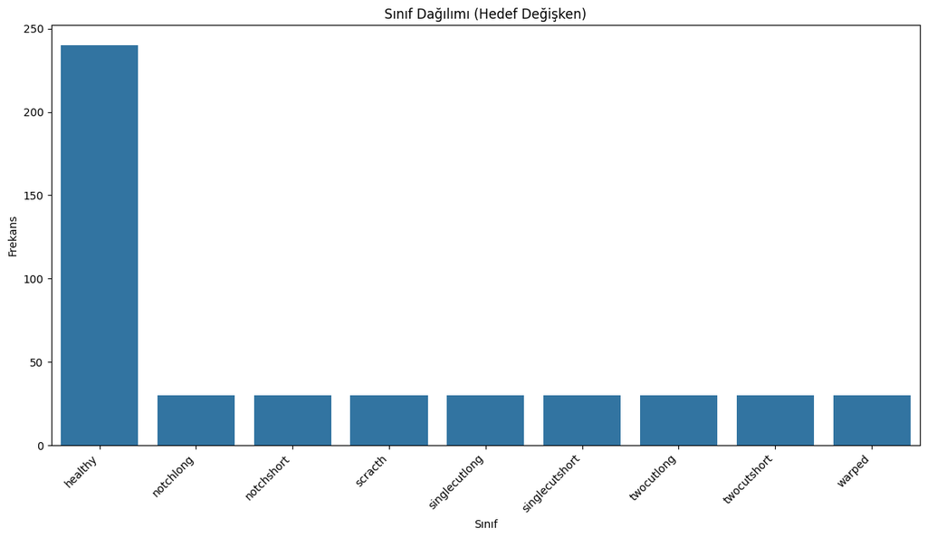

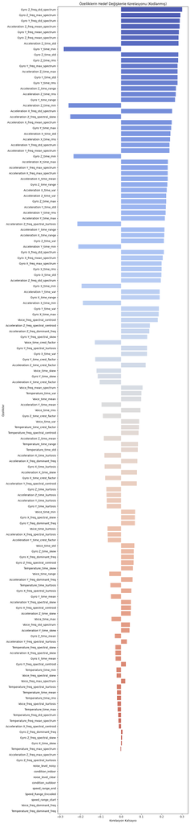

```
Too many features (143). Selecting 30 features with highest variance for heatmap.
```

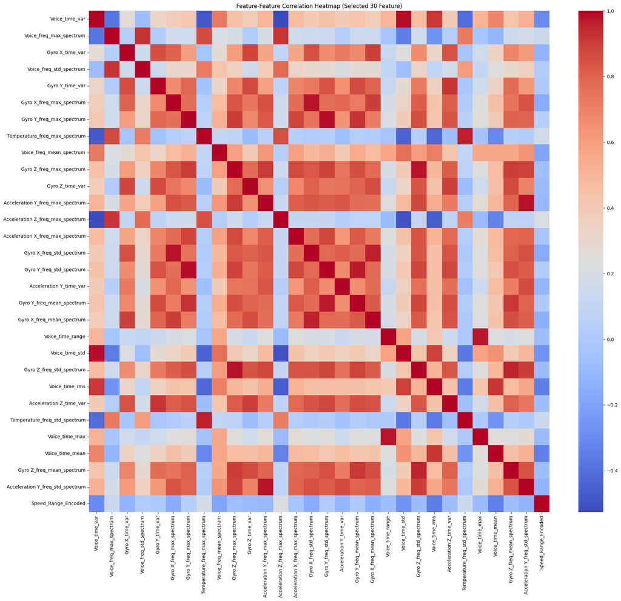

```python
import matplotlib.pyplot as plt
import seaborn as sns

print("\n--- Keşifsel Veri Analizi (EDA) ---")

plt.figure(figsize=(12, 7))
sns.countplot(x=y_series, order=y_series.value_counts().index)
plt.title('Sınıf Dağılımı (Hedef Değişken)')
plt.xlabel('Sınıf')
plt.ylabel('Frekans')
plt.xticks(rotation=45, ha='right')
plt.tight_layout()
plt.show()


correlations_with_target = X_processed_df.corrwith(pd.Series(y_encoded, name="Target_Encoded_for_Corr"))
if not correlations_with_target.empty:
    plt.figure(figsize=(10, max(8, len(correlations_with_target) * 0.3)))
    sorted_correlations = correlations_with_target.abs().sort_values(ascending=False)
    sns.barplot(x=correlations_with_target[sorted_correlations.index].values, y=sorted_correlations.index, palette="coolwarm")
    plt.title('Özelliklerin Hedef Değişkenle Korelasyonu (Kodlanmış)')
    plt.xlabel('Korelasyon Katsayısı')
    plt.ylabel('Özellikler')
    plt.tight_layout()
    plt.show()
else:
    print("Numerical property for correlation with target could not be found or calculated.")


sample_cols_for_heatmap = X_processed_df.columns
if X_processed_df.shape[1] > 40:
    print(f"\nToo many features ({X_processed_df.shape[1]}). Selecting 30 features with highest variance for heatmap.")
    top_variance_cols = X_processed_df.var().nlargest(30).index
    sample_cols_for_heatmap = top_variance_cols

    if 'Speed_Range_Encoded' in X_processed_df.columns and 'Speed_Range_Encoded' not in sample_cols_for_heatmap:
        sample_cols_for_heatmap = sample_cols_for_heatmap.tolist()
        if len(sample_cols_for_heatmap) >=30 : sample_cols_for_heatmap.pop()
        sample_cols_for_heatmap.append('Speed_Range_Encoded')


correlation_matrix = X_processed_df[sample_cols_for_heatmap].corr()
plt.figure(figsize=(min(20, len(sample_cols_for_heatmap)*0.8) , min(18, len(sample_cols_for_heatmap)*0.7)))
sns.heatmap(correlation_matrix, annot=False, cmap='coolwarm', fmt=".1f")
plt.title(f'Feature-Feature Correlation Heatmap (Selected {len(sample_cols_for_heatmap)} Feature)')
plt.xticks(rotation=90)
plt.yticks(rotation=0)
plt.tight_layout()
plt.show()
```

```python
from sklearn.model_selection import train_test_split, StratifiedKFold, cross_val_score
print("\n--- Veri Bölme ve Ölçekleme ---")

X_train, X_test, y_train, y_test = train_test_split(
    X_processed_df, y_encoded,
    test_size=0.2,
    random_state=RANDOM_SEED,
    stratify=y_encoded
)
print(f"X_train shape: {X_train.shape}, y_train shape: {y_train.shape}")
print(f"X_test shape: {X_test.shape}, y_test shape: {y_test.shape}")

# scale
scaler = StandardScaler()
X_train_scaled = scaler.fit_transform(X_train)
X_test_scaled = scaler.transform(X_test) # just transform!

print("\nÖzellikler StandardScaler ile ölçeklendi.")
print("X_train_scaled (First row):", X_train_scaled[0, :10]) # İlk 10 özelliği göster
```

```
--- Veri Bölme ve Ölçekleme ---
X_train shape: (384, 143), y_train shape: (384,)
X_test shape: (96, 143), y_test shape: (96,)

Özellikler StandardScaler ile ölçeklendi.
X_train_scaled (First row): [-0.86180216 -1.39780047  1.39780047 -0.71957387  0.71957387  1.20455493
  1.20455493 -0.39726416  0.35230007  0.20697435]
```

```python
import time
import joblib
from sklearn.linear_model import LogisticRegression
from sklearn.neighbors import KNeighborsClassifier
from sklearn.svm import SVC
from sklearn.tree import DecisionTreeClassifier
from sklearn.ensemble import RandomForestClassifier, GradientBoostingClassifier
import lightgbm as lgb
import xgboost as xgb
from sklearn.metrics import (accuracy_score, f1_score, precision_score, recall_score,classification_report, confusion_matrix, ConfusionMatrixDisplay)

print("\n--- Model Eğitimi ve Çapraz Doğrulama ---")

models = {
    "Logistic Regression": LogisticRegression(max_iter=1000, random_state=RANDOM_SEED, solver='liblinear'),
    "K-Nearest Neighbors": KNeighborsClassifier(),
    "Support Vector Machine": SVC(random_state=RANDOM_SEED, probability=True),
    "Decision Tree": DecisionTreeClassifier(random_state=RANDOM_SEED),
    "Random Forest": RandomForestClassifier(random_state=RANDOM_SEED, n_estimators=100),
    "Gradient Boosting": GradientBoostingClassifier(random_state=RANDOM_SEED, n_estimators=100),
    "LightGBM": lgb.LGBMClassifier(random_state=RANDOM_SEED, verbosity=-1),
    "XGBoost": xgb.XGBClassifier(random_state=RANDOM_SEED, use_label_encoder=False, eval_metric='mlogloss')
}


cv_results = []
skf = StratifiedKFold(n_splits=10, shuffle=True, random_state=RANDOM_SEED)

print("\nStarting cross validation (10-fold layered)...")
for model_name, model_instance in models.items():
    print(f" Model is being evaluated: {model_name}")

    fold_train_times = []
    fold_test_times = []
    fold_accuracy = []
    fold_f1_macro = []
    fold_precision_macro = []
    fold_recall_macro = []

    for fold_idx, (train_indices, val_indices) in enumerate(skf.split(X_train_scaled, y_train)):
        X_train_fold, X_val_fold = X_train_scaled[train_indices], X_train_scaled[val_indices]
        y_train_fold, y_val_fold = y_train[train_indices], y_train[val_indices]

        start_train_time = time.time()
        model_instance.fit(X_train_fold, y_train_fold)
        train_time = time.time() - start_train_time
        fold_train_times.append(train_time)

        start_test_time = time.time()
        y_pred_fold = model_instance.predict(X_val_fold)
        test_time = time.time() - start_test_time
        fold_test_times.append(test_time)

        fold_accuracy.append(accuracy_score(y_val_fold, y_pred_fold))
        fold_f1_macro.append(f1_score(y_val_fold, y_pred_fold, average='macro', zero_division=0))
        fold_precision_macro.append(precision_score(y_val_fold, y_pred_fold, average='macro', zero_division=0))
        fold_recall_macro.append(recall_score(y_val_fold, y_pred_fold, average='macro', zero_division=0))

    cv_results.append({
        "Model": model_name,
        "Mean CV Accuracy": np.mean(fold_accuracy),
        "Std CV Accuracy": np.std(fold_accuracy),
        "Mean CV F1 (Macro)": np.mean(fold_f1_macro),
        "Mean CV Precision (Macro)": np.mean(fold_precision_macro),
        "Mean CV Recall (Macro)": np.mean(fold_recall_macro),
        "Mean Training Time (s)": np.mean(fold_train_times),
        "Mean Inference Time (s)": np.mean(fold_test_times)
    })
    print(f"    {model_name} - Average CV F1 (Macro): {np.mean(fold_f1_macro):.4f}")

cv_results_df = pd.DataFrame(cv_results)
print("\n--- Çapraz Doğrulama Performans Özeti ---")
print(cv_results_df.sort_values(by="Mean CV F1 (Macro)", ascending=False))
```

```
--- Model Eğitimi ve Çapraz Doğrulama ---

Starting cross validation (10-fold layered)...
 Model is being evaluated: Logistic Regression
    Logistic Regression - Average CV F1 (Macro): 0.5229
 Model is being evaluated: K-Nearest Neighbors
    K-Nearest Neighbors - Average CV F1 (Macro): 0.3280
 Model is being evaluated: Support Vector Machine
    Support Vector Machine - Average CV F1 (Macro): 0.3054
 Model is being evaluated: Decision Tree
    Decision Tree - Average CV F1 (Macro): 0.5657
 Model is being evaluated: Random Forest
    Random Forest - Average CV F1 (Macro): 0.6792
 Model is being evaluated: Gradient Boosting
    Gradient Boosting - Average CV F1 (Macro): 0.7683
 Model is being evaluated: LightGBM
```

```
    LightGBM - Average CV F1 (Macro): 0.8040
 Model is being evaluated: XGBoost
```

[output not shown]

```
    XGBoost - Average CV F1 (Macro): 0.7436

--- Çapraz Doğrulama Performans Özeti ---
                    Model  Mean CV Accuracy  Std CV Accuracy  \
6                LightGBM          0.877463         0.035482
5       Gradient Boosting          0.846424         0.053976
7                 XGBoost          0.843792         0.048239
4           Random Forest          0.796829         0.045302
3           Decision Tree          0.719433         0.081507
0     Logistic Regression          0.703171         0.067666
1     K-Nearest Neighbors          0.601754         0.038143
2  Support Vector Machine          0.614440         0.043846

   Mean CV F1 (Macro)  Mean CV Precision (Macro)  Mean CV Recall (Macro)  \
6            0.804026                   0.844270                0.806920
```

[output cut: 17 more lines]

### 10. Final Evaluation, Reporting, and Saving the Best Model

This cell marks the culmination of our project. After identifying the best-performing model through cross-validation in the previous step, here we conduct a final test of that model, report its performance in detail, and save it for future use.

**Process Steps:**

1. **Identifying the Best Model:**
   - From the `cv_results_df` DataFrame containing the cross-validation results, the model with the highest Mean F1 Score (`Mean CV F1 (Macro)`) is selected.
   - This is the outcome of the project requirement to **"use stratified 10-fold cross validation to determine best"** model.
2. **Retraining the Model:**
   - Once the best model is chosen, it is retrained—not just on a single fold, but on the **entire training dataset (`X_train_scaled`, `y_train`)**.
   - This is standard practice to ensure the model learns from the maximum amount of available data before its final evaluation.
   - At this stage, the **training time** is measured, fulfilling one of the project's reporting requirements.
3. **Evaluating on the Test Set:**
   - The true measure of the model's success is its performance on the **test set (`X_test_scaled`)**, which it has never seen before.
   - The model makes predictions (`y_pred_test`) on the test set, and the **test time (inference time)** is recorded.
   - All performance metrics specified in the project requirements are calculated based on these test results:
     - `Accuracy`: The overall percentage of correct predictions.
     - `F1-score (Macro)`: The harmonic mean of precision and recall, averaged across classes, which accounts for class imbalance.
     - `Precision (Macro)`: The average ability of the classifier not to label a negative sample as positive.
     - `Recall (Macro)`: The average ability of the classifier to find all the positive samples.
4. **Detailed Performance Reports and Visualizations:**
   - **Classification Report:** This report precisely meets the project requirement to show performance metrics **for each class**. It provides precision, recall, and F1-score on a per-class basis, clearly showing where the model excels and where it struggles.
   - **Confusion Matrix:** As required by the project, this figure visualizes the model's errors. The diagonal elements represent correct classifications, while off-diagonal elements show which classes are being confused with one another. This is one of the most valuable tools for understanding the model's error patterns.
   - **Feature Importance Plot:** If supported by the chosen model (e.g., Random Forest or Logistic Regression), a bar chart is generated to show which features the model found most important when making decisions. This helps us interpret the model's "logic" and provides insights into which sensor data is most discriminative.
5. **Saving the Best Model:**
   - Finally, the fully trained and validated `best_model_final` object is saved to a file using the `joblib` library.
   - This allows the model to be loaded and used for predictions on new data in the future without needing to repeat the entire training process. This step makes the model "deployable."

```
--- En İyi Model Seçimi ve Test Seti Değerlendirmesi ---
Best Model model (According to CV F1 Macro): LightGBM (F1: 0.8040)

Retraining LightGBM model on all training data...
Tam eğitim süresi: 0.6003 saniye.

Evaluating LightGBM model on test set...
Test seti tahmin süresi: 0.0000 saniye.

Test Seti Performansı (LightGBM):
  Accuracy: 0.8229
  F1-score (Macro): 0.7721
  Precision (Macro): 0.8230
  Recall (Macro): 0.7662

Classification Report (Test Set):
                precision    recall  f1-score   support

       healthy       0.90      0.90      0.90        48
     notchlong       1.00      0.67      0.80         6
    notchshort       0.80      0.67      0.73         6
       scracth       0.44      0.67      0.53         6
 singlecutlong       0.60      1.00      0.75         6
singlecutshort       0.83      0.83      0.83         6
    twocutlong       1.00      0.83      0.91         6
   twocutshort       0.83      0.83      0.83         6
        warped       1.00      0.50      0.67         6

      accuracy                           0.82        96
     macro avg       0.82      0.77      0.77        96
  weighted avg       0.85      0.82      0.83        96
```

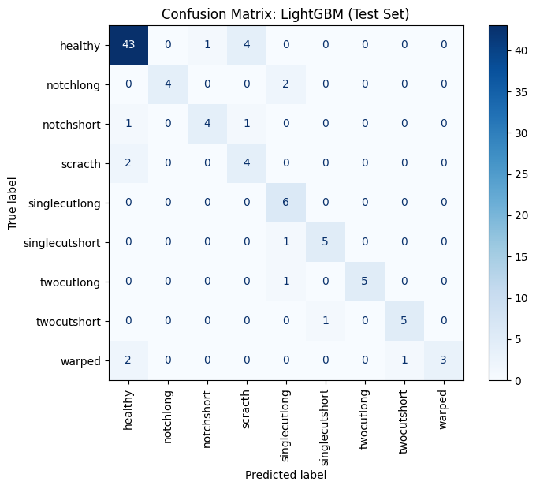

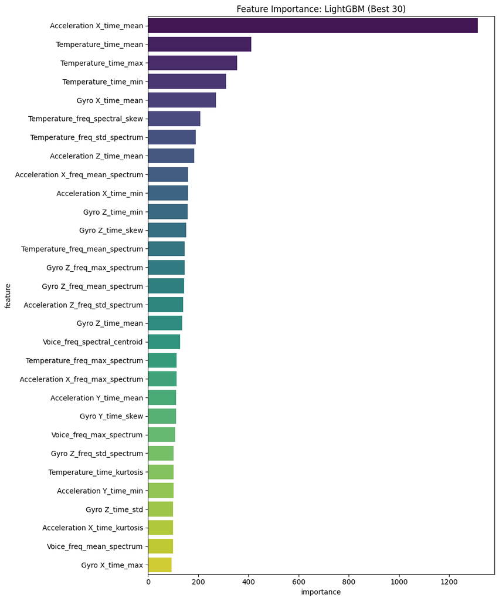

```
Best model (LightGBM) saved as 'outputs\PM980_best_model.joblib'.
```

```python
print("\n--- En İyi Model Seçimi ve Test Seti Değerlendirmesi ---")

best_model_row = cv_results_df.loc[cv_results_df["Mean CV F1 (Macro)"].idxmax()]
best_model_name = best_model_row["Model"]
# Rebuild the best model and train it with all training data (parameters do not come from CV, defined model)
best_model_final = models[best_model_name]

print(f"Best Model model (According to CV F1 Macro): {best_model_name} (F1: {best_model_row['Mean CV F1 (Macro)']:.4f})")

print(f"\nRetraining {best_model_name} model on all training data...")
start_full_train_time = time.time()
best_model_final.fit(X_train_scaled, y_train)
full_train_time = time.time() - start_full_train_time
print(f"Tam eğitim süresi: {full_train_time:.4f} saniye.")

print(f"\nEvaluating {best_model_name} model on test set...")
start_test_inference_time = time.time()
y_pred_test = best_model_final.predict(X_test_scaled)
test_inference_time = time.time() - start_test_inference_time
print(f"Test seti tahmin süresi: {test_inference_time:.4f} saniye.")

test_accuracy = accuracy_score(y_test, y_pred_test)
test_f1_macro = f1_score(y_test, y_pred_test, average='macro', zero_division=0)
test_precision_macro = precision_score(y_test, y_pred_test, average='macro', zero_division=0)
test_recall_macro = recall_score(y_test, y_pred_test, average='macro', zero_division=0)

print(f"\nTest Seti Performansı ({best_model_name}):")
print(f"  Accuracy: {test_accuracy:.4f}")
print(f"  F1-score (Macro): {test_f1_macro:.4f}")
print(f"  Precision (Macro): {test_precision_macro:.4f}")
print(f"  Recall (Macro): {test_recall_macro:.4f}")

print("\nClassification Report (Test Set):")
# encoded_class_names: label_encoder.classes_
report = classification_report(y_test, y_pred_test, target_names=encoded_class_names, zero_division=0)
print(report)

cm = confusion_matrix(y_test, y_pred_test)
disp = ConfusionMatrixDisplay(confusion_matrix=cm, display_labels=encoded_class_names)
fig, ax = plt.subplots(figsize=(max(8, len(encoded_class_names)*0.8), max(6, len(encoded_class_names)*0.7)))
disp.plot(ax=ax, cmap=plt.cm.Blues, xticks_rotation='vertical')
plt.title(f'Confusion Matrix: {best_model_name} (Test Set)')
plt.tight_layout()
plt.show()


feature_names_for_plot = X_train.columns

if hasattr(best_model_final, 'feature_importances_'):
    importances = best_model_final.feature_importances_
    feature_importance_df = pd.DataFrame({'feature': feature_names_for_plot, 'importance': importances})
    feature_importance_df = feature_importance_df.sort_values('importance', ascending=False).head(30) # Top 30

    plt.figure(figsize=(10, 12))
    sns.barplot(x='importance', y='feature', data=feature_importance_df, palette="viridis")
    plt.title(f'Feature Importance: {best_model_name} (Best 30)')
    plt.tight_layout()
    plt.show()
elif hasattr(best_model_final, 'coef_') and best_model_name == "Logistic Regression":
    if best_model_final.coef_.ndim > 1 and best_model_final.coef_.shape[0] > 1: # Multi-class
        importances = np.mean(np.abs(best_model_final.coef_), axis=0)
    else: # Binary
        importances = np.abs(best_model_final.coef_.ravel())

    feature_importance_df = pd.DataFrame({'feature': feature_names_for_plot, 'importance': importances})
    feature_importance_df = feature_importance_df.sort_values('importance', ascending=False).head(30)

    plt.figure(figsize=(10, 12))
    sns.barplot(x='importance', y='feature', data=feature_importance_df, palette="viridis")
    plt.title(f'Feature Importance (Abs Coefficients): {best_model_name} (Best 30)')
    plt.tight_layout()
    plt.show()
else:
    print(f"\nThe standard feature importance plot is not supported for the {best_model_name} model.")

os.makedirs('outputs', exist_ok=True) # Klasör yoksa oluştur
BEST_MODEL_FILE = os.path.join('outputs', f'PM980_best_model.joblib')
joblib.dump(best_model_final, BEST_MODEL_FILE)
print(f"\nBest model ({best_model_name}) saved as '{BEST_MODEL_FILE}'.")
```